# Introduction to Data Science: Fall 2022 Final Project

Finally, based on our results, we visualize variable importance for the Random Forest model to see which variables in our data set play the most important role in predicting the outcome i.e. corn yield.

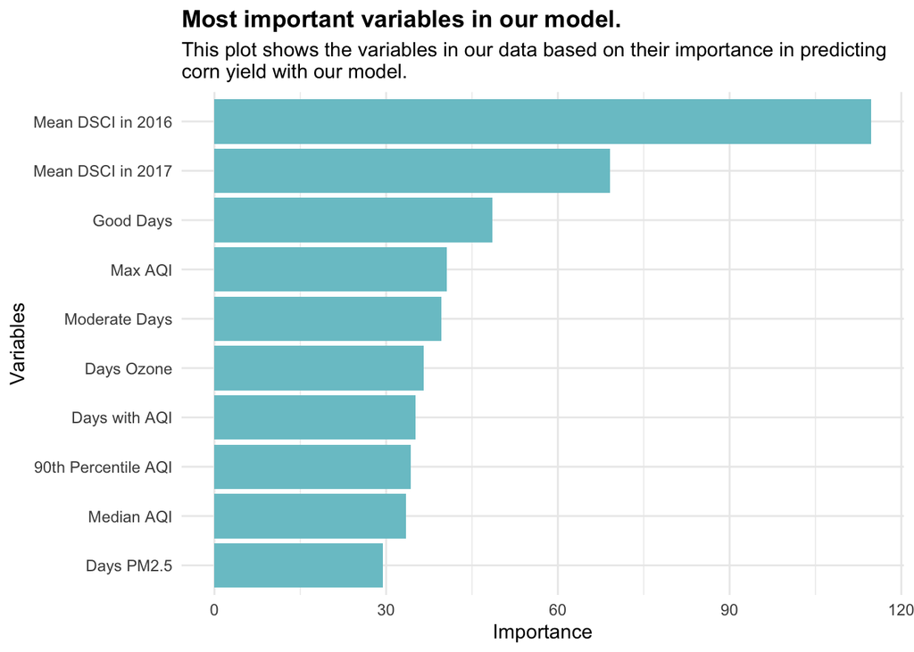

```r
corn_final_fit %>%
 extract_fit_parsnip() %>%
 vip(num_features = 10,
         aesthetics = list(fill = "cadetblue3", size = 2))+
  labs(title = "Most important variables in our model.",
subtitle = "This plot shows the variables in our data based on their importance in predicting\ncorn yield with our model.",
y = "Importance",
x = "Variables")+
  scale_x_discrete(labels= c("meanDSCI2016"="Mean DSCI in 2016", "meanDSCI2017"="Mean DSCI in 2017"))+
  theme_minimal()+
theme(plot.title = element_text(face="bold"))
```

The plot shows that mean Drought Severity and Coverage Index for 2016 and 2017 were the most important predictors in our model which is understandable considering drought levels effect crop yields. These are followed by air quality variables that measure good Air Quality Index days, days with highest AQI and moderate air quality days. Ozone concentration days, 90th percentile AQI, median AQI are also important predictors in our model but they show a lower importance. Conceptually, it makes sense that drought levels and Air Quality Index are the most important variables in predicting corn yield, as these variables affect the crops most directly throughout their growth cycle. Other metrics that we use to predict corn yields which have lower levels of importance, like the number of days which are “Unhealthy” or “Hazardous” are relatively infrequent in our data, which also could explain their low explanatory power, as these variables have little variance for the model to exploit. Finally, worse air quality current is concentrated in more urban areas, and therefore may have a lesser effect on crop production at this point in time, although the increase of air pollution events, like forest fires or increasing urban sprawl, could increase the importance of these variables in the future.

## *Conclusion and Looking Forward*

After data retrieval, cleaning, and merging, one of the more challenging aspects of this project was ultimately deciding which sorts of supervised machine learning models could work with the limited dataset we finalized. As demonstrated in the model section, we ultimately decided upon comparing a Lasso and a Random Forest model. After comparing the models on the basis of root mean square error, it was clear the random forest model better suited our data. However, it is also still clear that this random forest model is not perfect. As noted multiple times throughout this project, county-level data is quite hard to come by in the agricultural world. There are limited pools of data to use as predictors, and when measures exist, they are often not available for every county. When it came down to it, despite there being over 3,000 counties in the United States, we had a very short and a very narrow dataset of just over 600 observations. However, we made the most out of these limitations by using cross-validation to test different models and hyperparameter tuning. Although our models did not necessarily succeed in accuracy or precision, we still had an opportunity to see which variables were most useful in predicting corn production on the county level. It is exciting to know that even very limited data could potentially be used to predict crop production. We believe we could make this model even better if we had the time and the access to more data. We would like to include many more measures of climate and environmental health as well as technology usage, which definitely impact crop production. If these data were available to us publicly and on the county-level, we could have improved our predictive model simply through access to more predictors. We searched high and low for county-level public data on temperature, precipitation, weather events, soil health, soil pH, soil moisture, soil type, air humidity, fertilizer use, pesticide use, availability of genetically modified seeds, and many others. Despite these limitations in our own project, we believe that strengthening the model is possible. However, we do not believe that the average farm operator would have access to all this information. If she could use a model like ours to better predict her crop output, she may be able to adapt to other more useful technologies and farming techniques to make the most of her land, despite the negative impacts of climate change making the environment much more unpredictable.